# Machine Learning Recognition of Weight Lifting Exercises

Jeffrey Phillips

June 19, 2015

## Executive Summary

Based on data discovery and testing several different methods, it was determined that the R [Caret](http://caret.r-forge.r-project.org/) package would be used and model built using a [Random Forest](http://cran.r-project.org/web/packages/randomForest/index.html) for the Classification and Regression Tree model.

```r
# Load necessary libraries
library(caret)
library(ggplot2)
# Do things in parallel
# May need to install.packages("doParallel")
library(doParallel)
cl <- makeCluster(detectCores())
registerDoParallel(cl)
```

## Data Collection and Cleaning

First step is to download and read in the necessary data:

```r
download.file(url = "https://d396qusza40orc.cloudfront.net/predmachlearn/pml-training.csv",
              destfile = "pml-training.csv", method ="curl")
download.file(url = "https://d396qusza40orc.cloudfront.net/predmachlearn/pml-testing.csv",
              destfile = "pml-testing.csv", method ="curl")

# Load data from CSV, and remove first 7 columns that are more bookkeeping info.
training <- read.csv("pml-training.csv", na.strings = c("NA", "", " "))[,-(0:7)]
testing <- read.csv("pml-testing.csv", na.strings = c("NA", "", " "))[,-(0:7)]
```

```r
dim(training)
```

```
## [1] 19622   153
```

It was also found during exploration, that there were several columns with lots of missing data, and others with not much variation. Those columns were all removed from training and testing.

```r
# Remove columns that are heavy on NA's
hasData<-apply(!is.na(training),2,sum)>5000
training<-training[, hasData]
testing<-testing[, hasData]

# Remove columns with low variance
nzv <- nearZeroVar(training, allowParallel = TRUE)
training[, -nzv]
testing[, -nzv]
```

```r
# Now look at the resulting data
dim(training)
```

```
## [1] 19622    53
```

As you can see above, the number of columns has decreased to 53 columns which is much better compression of the data.

The **classe** column is the attribute that provides the **outcome** that predictors are trying to determine. As can be seen there are 5 levels of classe data: A, B, C, D, and E.

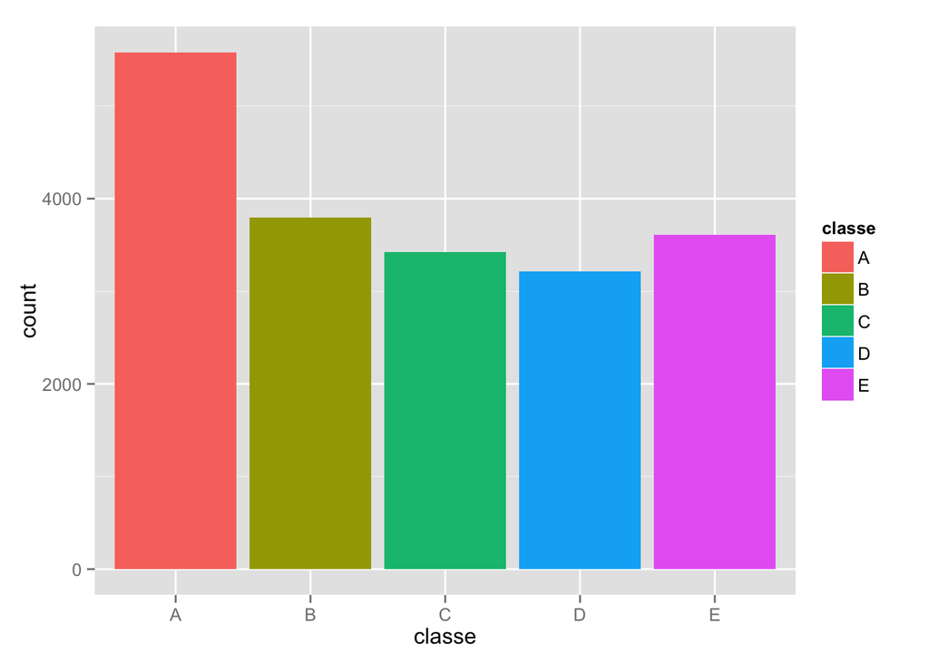

```r
qplot(classe, data = training, fill = classe)
```

Lastly, the original training data was split into 60% **train** dataset, and 40% **validate** dataset. This will allow training and validating model, without overfitting to actual test data.

```r
set.seed(22271)

# Partition data into train and validate train: 60%, validate: 40%
inTrain <- createDataPartition(y = training$classe, p = 0.6, list = FALSE)
train <- training[inTrain, ]
validate <- training[-inTrain, ]
```

## Random Forest Model Fit

Random Forest was chosen for model fitting. (Note: rpart was tried early, but was removed due to only having a 48% accuracy rate.)

```r
# Check accuracy using rpart - Note: was not too good at 48%, so commented
# modFit <- train(classe ~ ., data=train, method="rpart")
# pred <- predict(modFit, newdata=validate)
# print(paste("Accuracy rpart:",
#             confusionMatrix(validate$classe, pred)$overall[1]))

# Use Cross-Validation to help combat overfitting of random forest
trainCtl <- trainControl(method = "cv", number = 10,  allowParallel = TRUE)
modFit <- train(classe ~ ., data=train, method = "rf", ntree = 25,
                trainControl = trainCtl, importance = TRUE, prox=FALSE,
                allowParallel = TRUE)
```

Visually looking at some of the details for the model fit, there are some very good predictors and looks be tuned reasonably based on the number of important predictors and the Number of Trees used to train the model.

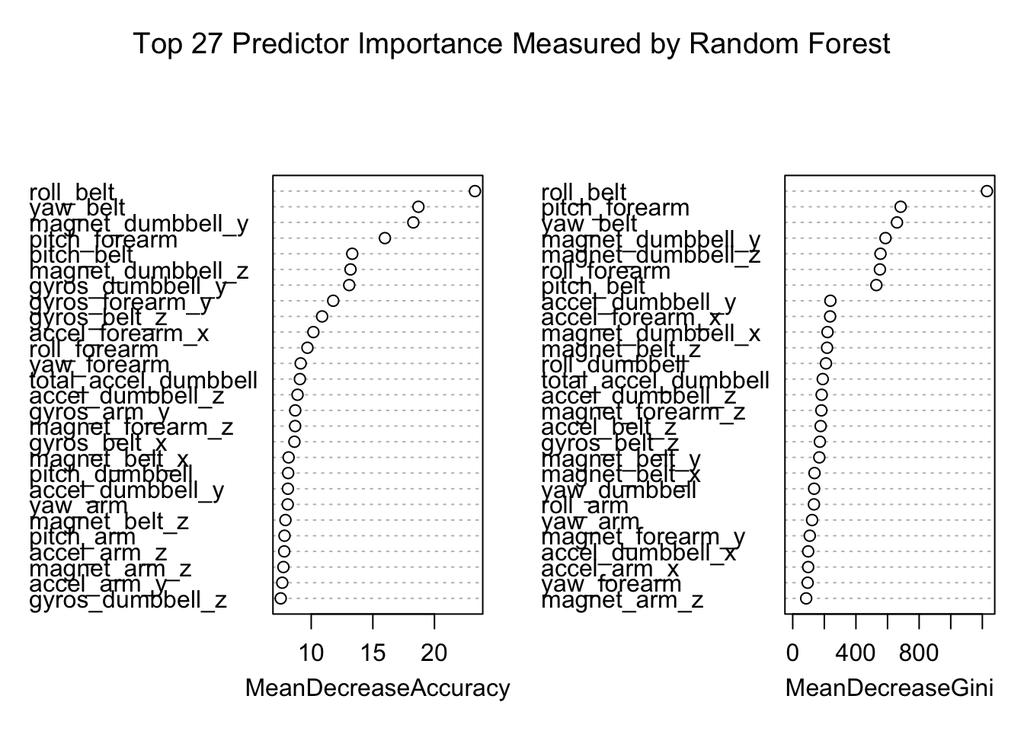

```r
varImpPlot(modFit$finalModel, n.var = 27, main = "Top 27 Predictor Importance Measured by Random Forest")
```

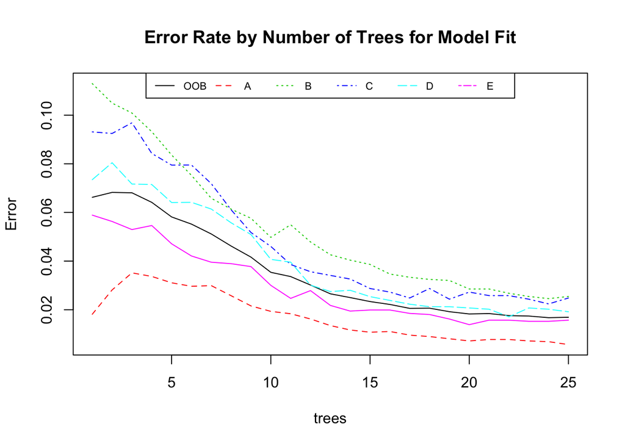

```r
plot(modFit$finalModel, main = "Error Rate by Number of Trees for Model Fit")
modFit$finalModel.legend <- if (is.null(modFit$finalModel$test$err.rate)) {
                colnames(modFit$finalModel$err.rate)
        } else {
                colnames(modFit$finalModel$test$err.rate)
        }
legend("top", cex =0.7, legend=modFit$finalModel.legend,
       lty=c(1:6), col=c(1:6), horiz=T)
```

## Results

```r
# Check out our accuracy for the model using confusionMatrix
pred <- predict(modFit, newdata = validate)
results <- confusionMatrix(validate$classe, pred)
print(results$table)
```

```
##           Reference
## Prediction    A    B    C    D    E
##          A 2227    2    2    1    0
##          B   16 1483   15    4    0
##          C    0    8 1352    8    0
##          D    3    0   26 1254    3
##          E    0    2    3   11 1426
```

```r
print(paste("Accuracy Random Forest:", results$overall[1]))
```

```
## [1] "Accuracy Random Forest: 0.986744838134081"
```

## Citation

Velloso, E.; Bulling, A.; Gellersen, H.; Ugulino, W.; Fuks, H. Qualitative Activity Recognition of Weight Lifting Exercises. Proceedings of 4th International Conference in Cooperation with SIGCHI (Augmented Human ’13) . Stuttgart, Germany: ACM SIGCHI, 2013.

Read more: http://groupware.les.inf.puc-rio.br/har#ixzz3diQxUgtz